# Story

Chirag Pandya

June 14, 2017

## The Question

The question to be answered here is “Given the previous data, who will win the next scheduled match?”. There are various factors affecting this prediction. This report shows the importance of some features which may prove significant for prediction and also identifies other features which I will calculate from the data sets. The importance of this calculated features can only be confirmed once I build a model for prediction.

## Data Sanity

The data is procured from a trusted source yet there are some sanity checks which are required to locate errors if any. I will start with reading the csv files.

```
## 'data.frame':    577 obs. of  18 variables:
##  $ id             : int  1 2 3 4 5 6 7 8 9 10 ...
##  $ season         : int  2008 2008 2008 2008 2008 2008 2008 2008 2008 2008 ...
##  $ city           : Factor w/ 31 levels "","Abu Dhabi",..: 4 8 11 23 22 17 15 9 15 8 ...
##  $ date           : Factor w/ 407 levels "2008-04-18","2008-04-19",..: 1 2 2 3 3 4 5 6 7 8 ...
##  $ team1          : Factor w/ 13 levels "Chennai Super Kings",..: 7 1 10 8 2 5 2 1 2 5 ...
##  $ team2          : Factor w/ 13 levels "Chennai Super Kings",..: 12 5 3 12 7 10 3 8 10 8 ...
##  $ toss_winner    : Factor w/ 13 levels "Chennai Super Kings",..: 12 1 10 8 2 5 2 8 10 8 ...
##  $ toss_decision  : Factor w/ 2 levels "bat","field": 2 1 1 1 1 1 1 2 2 2 ...
##  $ result         : Factor w/ 3 levels "no result","normal",..: 2 2 2 2 2 2 2 2 2 2 ...
##  $ dl_applied     : int  0 0 0 0 0 0 0 0 0 0 ...
##  $ winner         : Factor w/ 14 levels "","Chennai Super Kings",..: 8 2 4 13 8 11 4 2 11 6 ...
##  $ win_by_runs    : int  140 33 0 0 0 0 0 6 0 66 ...
##  $ win_by_wickets : int  0 0 9 5 5 6 9 0 3 0 ...
##  $ player_of_match: Factor w/ 188 levels "","A Chandila",..: 26 100 101 117 42 171 181 107 185 76 ...
##  $ venue          : Factor w/ 35 levels "Barabati Stadium",..: 15 23 9 35 8 27 24 16 24 23 ...
##  $ umpire1        : Factor w/ 43 levels "A Nand Kishore",..: 6 26 4 38 9 4 19 16 6 4 ...
##  $ umpire2        : Factor w/ 45 levels "A Nand Kishore",..: 29 40 14 13 19 28 5 14 23 5 ...
##  $ umpire3        : logi  NA NA NA NA NA NA ...
```

```
## 'data.frame':    136598 obs. of  21 variables:
##  $ match_id        : int  1 1 1 1 1 1 1 1 1 1 ...
##  $ inning          : int  1 1 1 1 1 1 1 1 1 1 ...
##  $ batting_team    : Factor w/ 13 levels "Chennai Super Kings",..: 7 7 7 7 7 7 7 7 7 7 ...
##  $ bowling_team    : Factor w/ 13 levels "Chennai Super Kings",..: 12 12 12 12 12 12 12 12 12 12 ...
##  $ over            : int  1 1 1 1 1 1 1 2 2 2 ...
##  $ ball            : int  1 2 3 4 5 6 7 1 2 3 ...
##  $ batsman         : Factor w/ 436 levels "A Ashish Reddy",..: 354 61 61 61 61 61 61 61 61 61 ...
##  $ non_striker     : Factor w/ 431 levels "A Ashish Reddy",..: 61 352 352 352 352 352 352 352 352 352 ...
##  $ bowler          : Factor w/ 334 levels "A Ashish Reddy",..: 204 204 204 204 204 204 204 334 334 334 ...
##  $ is_super_over   : int  0 0 0 0 0 0 0 0 0 0 ...
##  $ wide_runs       : int  0 0 1 0 0 0 0 0 0 0 ...
##  $ bye_runs        : int  0 0 0 0 0 0 0 0 0 0 ...
##  $ legbye_runs     : int  1 0 0 0 0 0 1 0 0 0 ...
##  $ noball_runs     : int  0 0 0 0 0 0 0 0 0 0 ...
##  $ penalty_runs    : int  0 0 0 0 0 0 0 0 0 0 ...
##  $ batsman_runs    : int  0 0 0 0 0 0 0 0 4 4 ...
##  $ extra_runs      : int  1 0 1 0 0 0 1 0 0 0 ...
##  $ total_runs      : int  1 0 1 0 0 0 1 0 4 4 ...
##  $ player_dismissed: Factor w/ 413 levels "","A Ashish Reddy",..: 1 1 1 1 1 1 1 1 1 1 ...
##  $ dismissal_kind  : Factor w/ 10 levels "","bowled","caught",..: 1 1 1 1 1 1 1 1 1 1 ...
##  $ fielder         : Factor w/ 422 levels "","A Ashish Reddy",..: 1 1 1 1 1 1 1 1 1 1 ...
```

Starting with season, the dataset contains data for 9 seasons so there should be 9 distinct values of season in the whole set and values from 2008 to 2016.

```
## [1] 2008 2009 2010 2011 2012 2013 2014 2015 2016
```

Moving forward plotting the value of city will show if there are any outliers.

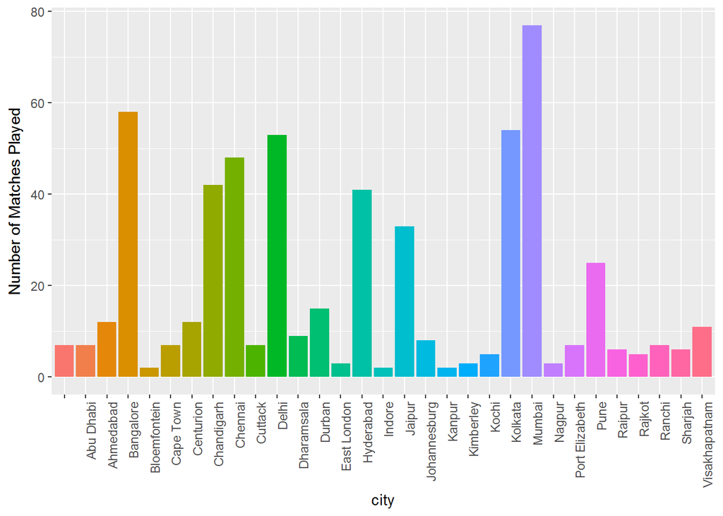

The plot shows there are some blank values in the city. On further exploration, it was found that the city column was empty for matches in Dubai in the year 2014. This has been taken care of in the code. There are less number of matches in venues of South Africa as IPL 2009 was not held in India, due to the differences of Lalit Modi - Chairperson for IPL and the Indian home ministry.

Moving on the team columns should have 13 unique values as there have been 13 teams participating in IPL over 9 years. This is confirmed by the following.

```
##  [1] Kolkata Knight Riders       Chennai Super Kings
##  [3] Rajasthan Royals            Mumbai Indians
##  [5] Deccan Chargers             Kings XI Punjab
##  [7] Royal Challengers Bangalore Delhi Daredevils
##  [9] Kochi Tuskers Kerala        Pune Warriors
## [11] Sunrisers Hyderabad         Rising Pune Supergiants
## [13] Gujarat Lions
## 13 Levels: Chennai Super Kings Deccan Chargers ... Sunrisers Hyderabad
```

```
##  [1] Royal Challengers Bangalore Kings XI Punjab
##  [3] Delhi Daredevils            Kolkata Knight Riders
##  [5] Rajasthan Royals            Mumbai Indians
##  [7] Chennai Super Kings         Deccan Chargers
##  [9] Pune Warriors               Kochi Tuskers Kerala
## [11] Sunrisers Hyderabad         Rising Pune Supergiants
## [13] Gujarat Lions
## 13 Levels: Chennai Super Kings Deccan Chargers ... Sunrisers Hyderabad
```

Similary the toss decision variable should have a binary value of field or bat.

```
## [1] field bat
## Levels: bat field
```

Winner will have 14 distinct values i.e 13 for the teams and 1 when the match is tied.

```
##  [1] Kolkata Knight Riders       Chennai Super Kings
##  [3] Delhi Daredevils            Royal Challengers Bangalore
##  [5] Rajasthan Royals            Kings XI Punjab
##  [7] Deccan Chargers             Mumbai Indians
##  [9] Pune Warriors               Kochi Tuskers Kerala
## [11]                             Sunrisers Hyderabad
## [13] Rising Pune Supergiants     Gujarat Lions
## 14 Levels:  Chennai Super Kings Deccan Chargers ... Sunrisers Hyderabad
```

To find the number of outliers for the “win_by_runs” and “win_by_wickets” I have plotted both variables against the number of matches. This should give a fair idea if there is something wrong in the data.

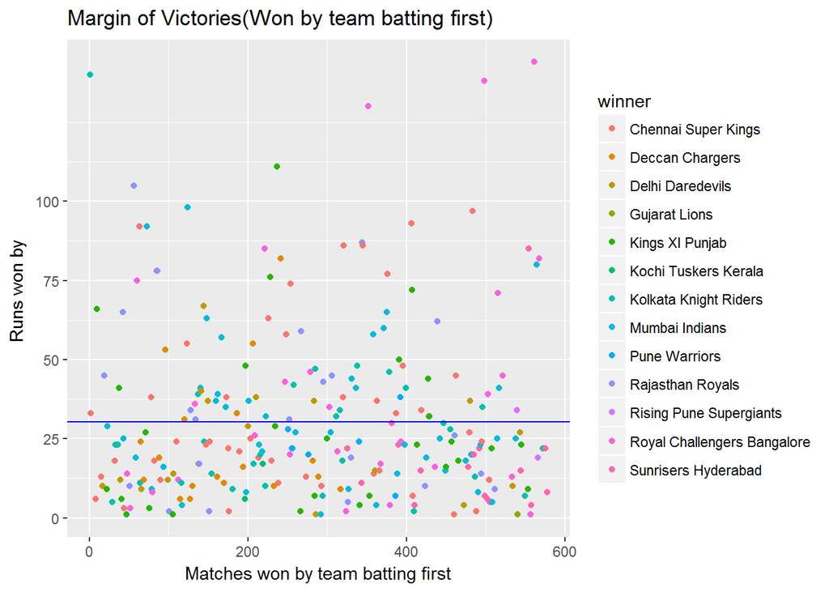

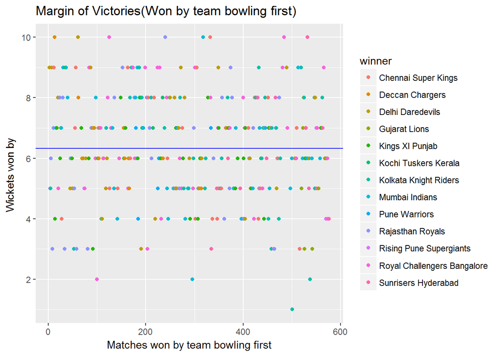

There are not more than 5 matches out of 577 which we can caetgorize as unusual. This is possible and hence no cleaning or exploration is required.

## Exploration

I will start exploring the most basic features which contributes to the sentiments of the winning team. The first feature which I explore is toss statistics. I have plotted a graph to depict the behaviour of each team on winning or losing a toss. For that we add two more variables namely toss_match and winner_do. These variables show the team who won the toss won the match or not and what did the winning team opt for, i.e bat or field.

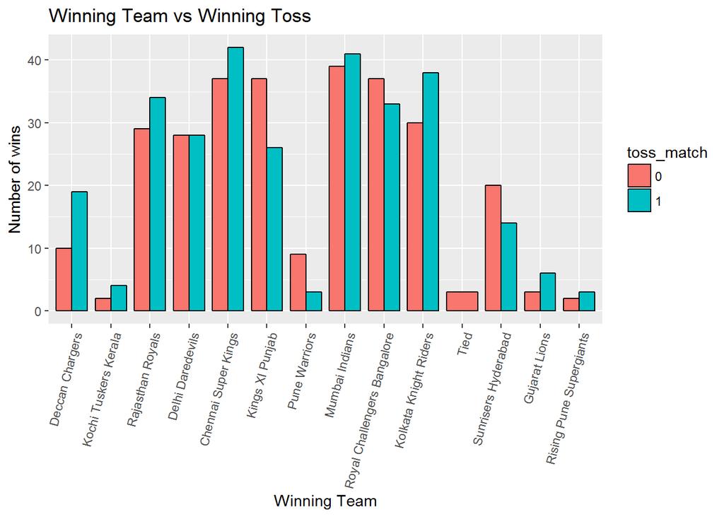

The plot shows that most teams have a higher winning percentage when they win the toss. The next feature which I will explore is “what does a winning team elect for: Bat OR Field”. THis is to find out if there is a significant relevance of winning teams opting to bat or field first.

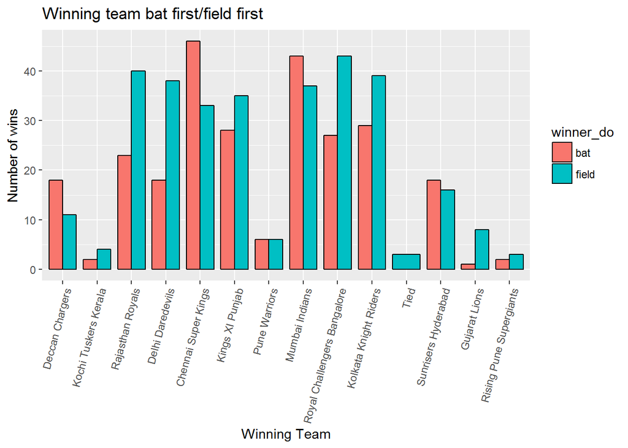

There are some very interesting fact depicted in this graph. The team Gujarat Lions seems to win most if it elects to field first. On the other hand teams like Chenna Superkings and Deccan chargers do well if they elect to bat first. Eventually, I will add a feature depicting whether the team elected to bat or field first.

Third imporant feature amongst others is the performance of teams on home and away grounds. I beleived that teams playing on their home grounds would perform better. The graph depics the winning percentage of teams depending upon the location i.e “Home” or “Away”

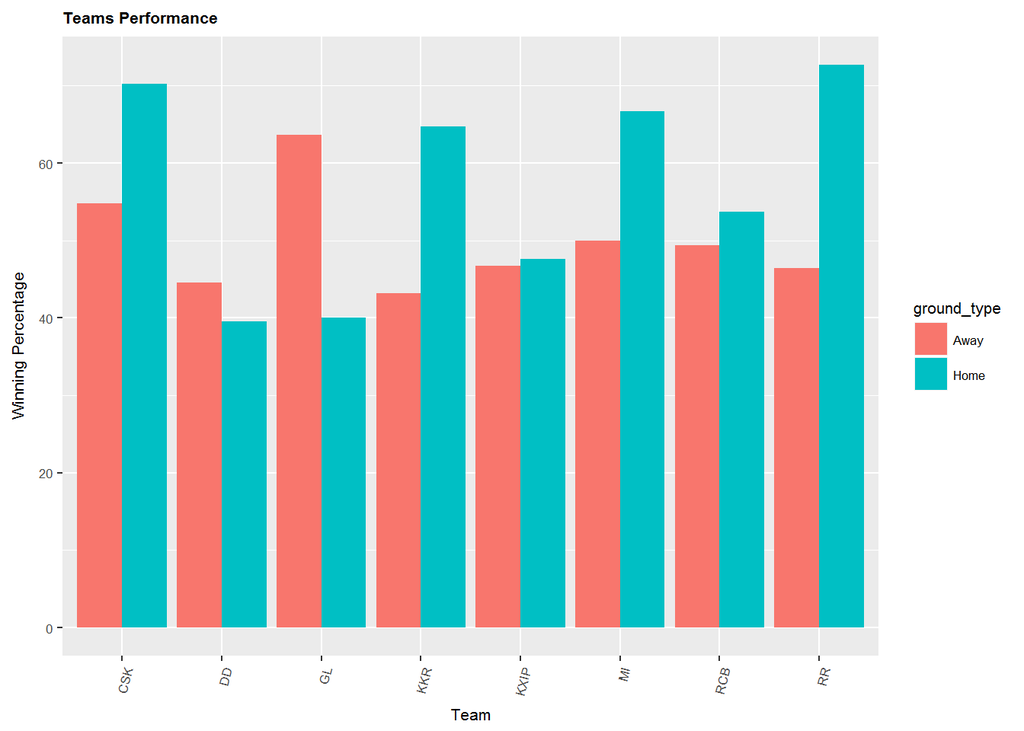

It seems that most teams perform well in their home grounds. Except for Gujarat Lions and Delhi Daredevils. On digging deeper, we find that Gujarat Lions have played only 16 matches as the team was formulated in 2016. Out of these 16 matches, they have played only 5 matches on their home ground. From these, they have won 2 matches. This is the reason for the anomaly in the graph and the data is too small to make a generalized statement about the team. This also depicts that predicting results for the team of Gujarat Lions may result in lesser accuracy. It may also be required to drop predictions for Gujarat Lions.

The following table shows the total number of matches played by each team on their home ground and away ground and their winning percentages. This should give a fair idea of the imporatance of home and away grounds.

```
##    team ground_type total_match_played total_win winning_perc
## 1   CSK        Away                 84        46     54.76190
## 2   CSK        Home                 47        33     70.21277
## 3    DD        Away                 83        37     44.57831
## 4    DD        Home                 48        19     39.58333
## 5   KKR        Away                 81        35     43.20988
## 6   KKR        Home                 51        33     64.70588
## 7    MI        Away                 80        40     50.00000
## 8    MI        Home                 60        40     66.66667
## 9  KXIP        Away                 92        43     46.73913
## 10 KXIP        Home                 42        20     47.61905
## 11  RCB        Away                 83        41     49.39759
## 12  RCB        Home                 54        29     53.70370
## 13   RR        Away                 84        39     46.42857
## 14   RR        Home                 33        24     72.72727
## 15   GL        Away                 11         7     63.63636
## 16   GL        Home                  5         2     40.00000
```

These are some of the performance metrics which affect team performance and may help in predicting wins in the future. The next section is about identify a feature vector to be provided to the model for prediction.

## Feature Vector

The following are the suggested feature vectors. This list may change with time as per the deductions of importance from the model’s Beta and t values.

### Percentage of matches won by team 1

int

### Number of matches won by team 1

int

### Winning record (Number of matches won - number of matches lost)

ternary int  
positive value = 1  
equal value = 0  
negative value = 1

### Team1 home/away

Binary int  
home = 1  
away = 0

### Team2 home/away

Binary int  
home = 1  
away = 0

### Team1 toss win

binary int  
win = 1  
lose = 0

### Team2 toss win

binary int  
win = 1  
lose = 0

### Team1 net run rate i.e runrate of team1 - run rate of team2

float

### Team2 net run rate i.e runrate of team2 - run rate of team1

float

### Average run rate of team1

float

### Average run rate of team2

float

### Average wicket rate per over team1

int (rounded)

### Average wicket rate per over team2

int(rounded)